# Pandas-Bootcamp-Part7

### Multi Level Indexes

#### Highlights:

```
- Creating and Using Advanced Index Structures
- Slicing , Sorting , Swapping , shuffling  and Pivoting Index levels
- Cross Sections , label and position based selection
- A closer look at the internals of Multi-Index
```

#### Introducing New Data

- Dataset contains daily stock price information for the past 5 and a half years for 5 of the largest US Technology companies
- Apple , Facebook , Google , Microsoft and Amazon
- https://andybek.com/pandas-tech

```python
import numpy as np
import pandas as pd
```

```python
tech = pd.read_csv('tech_giants.csv')
```

```python
tech.head(4)
```

|  | date | month | year | day | name | open | close | high | low | volume | volume_type |
| --- | --- | --- | --- | --- | --- | --- | --- | --- | --- | --- | --- |
| 0 | 2014-01-02 | 1 | 2014 | 2 | FB | 54.86 | 54.71 | 55.22 | 54.19 | 43257622 | medium |
| 1 | 2014-01-02 | 1 | 2014 | 2 | AAPL | 79.38 | 79.02 | 79.58 | 78.86 | 8398851 | low |
| 2 | 2014-01-02 | 1 | 2014 | 2 | GOOGL | 557.73 | 556.56 | 558.88 | 554.13 | 1822719 | medium |
| 3 | 2014-01-02 | 1 | 2014 | 2 | MSFT | 37.35 | 37.16 | 37.40 | 37.10 | 30643745 | medium |

- we have date in the first column
- The same date is decomposed into 'month' , 'year' and 'day'
- The Name column contains company's Ticker symbol

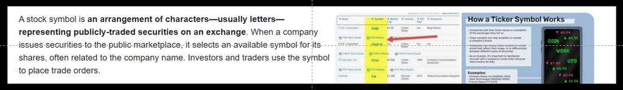

https://www.udemy.com/course/the-ultimate-pandas-bootcamp-advanced-python-data-analysis/learn/lecture/19196122#questions/13647656

- Then , in terms of 'Price' data , we have the 'open' price
- This is securities have been trading at
- 'close' is the price they finish trading at
- 'high' : is the highest price realised during the trading section
- 'low' : is the lowest price
- 'high' and 'low' are Intra-Day measures - During the Day how high or how low did the price go

Intraday means "within the day." In the financial world, the term is shorthand used to describe securities that trade on the markets during regular business hours. These securities include stocks and exchange-traded funds (ETFs). Intraday also signifies the highs and lows that the asset crossed throughout the day.

- 'volume' is the sub-total of sub-total of securities that changed hands
- We can see that Facebook , on Jan 2014 (month : 1) had massive trading volume : 43257622 compared to APPLE and GOOGLE

```python
#shape of the df
tech.shape
```

```
(7105, 11)
```

```python
#For each year we have about 1250 records
tech.year.value_counts()
```

```
2015    1260
2014    1260
2016    1260
2018    1255
2017    1255
2019     815
Name: year, dtype: int64
```

```python
#We have about 5 full years of data and half of 2019
#We look at the year wise data divided by the number of companies
tech.year.value_counts()/5
```

```
2015    252.0
2014    252.0
2016    252.0
2018    251.0
2017    251.0
2019    163.0
Name: year, dtype: float64
```

```python
#info
tech.info()
```

```
<class 'pandas.core.frame.DataFrame'>
RangeIndex: 7105 entries, 0 to 7104
Data columns (total 11 columns):
 #   Column       Non-Null Count  Dtype
---  ------       --------------  -----
 0   date         7105 non-null   object
 1   month        7105 non-null   int64
 2   year         7105 non-null   int64
 3   day          7105 non-null   int64
 4   name         7105 non-null   object
 5   open         7105 non-null   float64
 6   close        7105 non-null   float64
 7   high         7105 non-null   float64
 8   low          7105 non-null   float64
 9   volume       7105 non-null   int64
 10  volume_type  7105 non-null   object
dtypes: float64(4), int64(4), object(3)
memory usage: 610.7+ KB
```

- we have 4 float columns
- we have 4 int columns
- 3 Object columns for 'date' and 'name' and 'volume_type

### Index and RangeIndex

```python
#If we isolate the index of our dataframe we can see that its a RangeIndex object
type(tech.index)
```

```
pandas.core.indexes.range.RangeIndex
```

A Range Index is an immutable or unchangeable object that represents a Series of increasing or decreasing integers. A Range Index is inherited from Index.

```python
#columns is also a type of index
type(tech.columns)
```

```
pandas.core.indexes.base.Index
```

#### Index is an ordered Numpy Array that is Sliceable

Often times we want to replace the RangeIndex with something more meaningful set of Labels.

- We have seen how to do that with set_index() method

```python
tech.set_index('date')
```

| date | month | year | day | name | open | close | high | low | volume | volume_type |
| --- | --- | --- | --- | --- | --- | --- | --- | --- | --- | --- |
| 2014-01-02 | 1 | 2014 | 2 | FB | 54.86 | 54.71 | 55.22 | 54.19 | 43257622 | medium |
| 2014-01-02 | 1 | 2014 | 2 | AAPL | 79.38 | 79.02 | 79.58 | 78.86 | 8398851 | low |
| 2014-01-02 | 1 | 2014 | 2 | GOOGL | 557.73 | 556.56 | 558.88 | 554.13 | 1822719 | medium |
| 2014-01-02 | 1 | 2014 | 2 | MSFT | 37.35 | 37.16 | 37.40 | 37.10 | 30643745 | medium |
| 2014-01-02 | 1 | 2014 | 2 | AMZN | 398.80 | 397.97 | 399.36 | 394.02 | 2140246 | medium |
| ... | ... | ... | ... | ... | ... | ... | ... | ... | ... | ... |
| 2019-08-23 | 8 | 2019 | 23 | MSFT | 137.19 | 133.39 | 138.35 | 132.80 | 38515386 | medium |
| 2019-08-23 | 8 | 2019 | 23 | AAPL | 209.43 | 202.64 | 212.05 | 201.00 | 46882843 | medium |
| 2019-08-23 | 8 | 2019 | 23 | GOOGL | 1185.17 | 1153.58 | 1195.67 | 1150.00 | 1813141 | medium |
| 2019-08-23 | 8 | 2019 | 23 | AMZN | 1793.03 | 1749.62 | 1804.90 | 1745.23 | 5277898 | medium |
| 2019-08-23 | 8 | 2019 | 23 | FB | 180.84 | 177.75 | 183.13 | 176.66 | 17331221 | medium |

7105 rows × 10 columns

```python
#we can now use .loc indexer this way
tech.set_index('date').loc['2019-08-01']
```

| date | month | year | day | name | open | close | high | low | volume | volume_type |
| --- | --- | --- | --- | --- | --- | --- | --- | --- | --- | --- |
| 2019-08-01 | 8 | 2019 | 1 | GOOGL | 1217.63 | 1211.78 | 1236.30 | 1207.00 | 1771271 | medium |
| 2019-08-01 | 8 | 2019 | 1 | FB | 194.17 | 192.73 | 198.47 | 190.88 | 17777013 | medium |
| 2019-08-01 | 8 | 2019 | 1 | MSFT | 137.00 | 138.06 | 140.94 | 136.93 | 40557502 | medium |
| 2019-08-01 | 8 | 2019 | 1 | AMZN | 1871.72 | 1855.32 | 1897.92 | 1844.01 | 4713311 | medium |
| 2019-08-01 | 8 | 2019 | 1 | AAPL | 213.90 | 208.43 | 218.03 | 206.74 | 54017922 | medium |

- we see all the records with the date "2019-08-01"

```python
#This gives us the same Output
tech.loc[tech['date'] == '2019-08-01']
```

|  | date | month | year | day | name | open | close | high | low | volume | volume_type |
| --- | --- | --- | --- | --- | --- | --- | --- | --- | --- | --- | --- |
| 7020 | 2019-08-01 | 8 | 2019 | 1 | GOOGL | 1217.63 | 1211.78 | 1236.30 | 1207.00 | 1771271 | medium |
| 7021 | 2019-08-01 | 8 | 2019 | 1 | FB | 194.17 | 192.73 | 198.47 | 190.88 | 17777013 | medium |
| 7022 | 2019-08-01 | 8 | 2019 | 1 | MSFT | 137.00 | 138.06 | 140.94 | 136.93 | 40557502 | medium |
| 7023 | 2019-08-01 | 8 | 2019 | 1 | AMZN | 1871.72 | 1855.32 | 1897.92 | 1844.01 | 4713311 | medium |
| 7024 | 2019-08-01 | 8 | 2019 | 1 | AAPL | 213.90 | 208.43 | 218.03 | 206.74 | 54017922 | medium |

### Creating a Multiindex

Using more than one field as the index for our Dataframe

- This time we will pass in a list of strings instead of date

```python
#We want both 'date' and 'name' to act as a 'index'
tech.set_index(['date' , 'name']).iloc[0]
```

```
month                 1
year               2014
day                   2
open              54.86
close             54.71
high              55.22
low               54.19
volume         43257622
volume_type      medium
Name: (2014-01-02, FB), dtype: object
```

```python
#inplace = True
tech.set_index(['date' , 'name'] , inplace = True)
```

```python
#Two output the first two dates we would have to look at the first 10 records
tech.head(10)
```

| date | name | month | year | day | open | close | high | low | volume | volume_type |
| --- | --- | --- | --- | --- | --- | --- | --- | --- | --- | --- |
| 2014-01-02 | FB | 1 | 2014 | 2 | 54.86 | 54.71 | 55.22 | 54.19 | 43257622 | medium |
|  | AAPL | 1 | 2014 | 2 | 79.38 | 79.02 | 79.58 | 78.86 | 8398851 | low |
|  | GOOGL | 1 | 2014 | 2 | 557.73 | 556.56 | 558.88 | 554.13 | 1822719 | medium |
|  | MSFT | 1 | 2014 | 2 | 37.35 | 37.16 | 37.40 | 37.10 | 30643745 | medium |
|  | AMZN | 1 | 2014 | 2 | 398.80 | 397.97 | 399.36 | 394.02 | 2140246 | medium |
| 2014-01-03 | FB | 1 | 2014 | 3 | 55.00 | 54.56 | 55.65 | 54.53 | 38287706 | medium |
|  | GOOGL | 1 | 2014 | 3 | 557.50 | 552.50 | 558.47 | 552.47 | 1669229 | medium |
|  | MSFT | 1 | 2014 | 3 | 37.20 | 36.91 | 37.22 | 36.60 | 31134795 | medium |
|  | AAPL | 1 | 2014 | 3 | 79.00 | 77.28 | 79.10 | 77.20 | 14043410 | low |
|  | AMZN | 1 | 2014 | 3 | 398.29 | 396.44 | 402.71 | 396.22 | 2213512 | medium |

- A multiindex is also known as the Hierarchical Index
- The left side of the Dataframe , now has the 'date' and within each date, there is the 'name' of the stock
- Its not only the appearance we are chaging here but it is the associations within our dataset

```python
#Verify its a multiindex
type(tech.index)
```

```
pandas.core.indexes.multi.MultiIndex
```

### Create Multiindex when reading the data / csv

- We have seen above how to create MultiIndex from our technology stocks dataset
- Lets look at how we create MultiIndex when reading the csv

#### parameter : "index_col"

"index_col" : Columns to use as row labels of the Dataframe , either given as string name or column index. If a Sequence of int/str is given , a MultiIndex is used.

Note : Index_col = False : To not use the first column as Index.

```python
#read the data
pd.read_csv('tech_giants.csv' , index_col = ['date' , 'name'])
```

| date | name | month | year | day | open | close | high | low | volume | volume_type |
| --- | --- | --- | --- | --- | --- | --- | --- | --- | --- | --- |
| 2014-01-02 | FB | 1 | 2014 | 2 | 54.86 | 54.71 | 55.22 | 54.19 | 43257622 | medium |
|  | AAPL | 1 | 2014 | 2 | 79.38 | 79.02 | 79.58 | 78.86 | 8398851 | low |
|  | GOOGL | 1 | 2014 | 2 | 557.73 | 556.56 | 558.88 | 554.13 | 1822719 | medium |
|  | MSFT | 1 | 2014 | 2 | 37.35 | 37.16 | 37.40 | 37.10 | 30643745 | medium |
|  | AMZN | 1 | 2014 | 2 | 398.80 | 397.97 | 399.36 | 394.02 | 2140246 | medium |
| ... | ... | ... | ... | ... | ... | ... | ... | ... | ... | ... |
| 2019-08-23 | MSFT | 8 | 2019 | 23 | 137.19 | 133.39 | 138.35 | 132.80 | 38515386 | medium |
|  | AAPL | 8 | 2019 | 23 | 209.43 | 202.64 | 212.05 | 201.00 | 46882843 | medium |
|  | GOOGL | 8 | 2019 | 23 | 1185.17 | 1153.58 | 1195.67 | 1150.00 | 1813141 | medium |
|  | AMZN | 8 | 2019 | 23 | 1793.03 | 1749.62 | 1804.90 | 1745.23 | 5277898 | medium |
|  | FB | 8 | 2019 | 23 | 180.84 | 177.75 | 183.13 | 176.66 | 17331221 | medium |

7105 rows × 9 columns